# **Analysis of the results of activity monitoring**

### Introduction

It is now possible to collect a large amount of data about personal movement using activity monitoring devices such as a Fitbit, Nike Fuelband, or Jawbone Up. These type of devices are part of the “quantified self” movement – a group of enthusiasts who take measurements about themselves regularly to improve their health, to find patterns in their behavior, or because they are tech geeks. But these data remain under-utilized both because the raw data are hard to obtain and there is a lack of statistical methods and software for processing and interpreting the data.

This project makes use of data from a personal activity monitoring device. This device collects data at 5 minute intervals through out the day. The data consists of two months of data from an anonymous individual collected during the months of October and November, 2012 and include the number of steps taken in 5 minute intervals each day.

#### *1. Loading and preprocessing the data*

Reading the data from the “activity.csv”

```r
library("data.table")
library(ggplot2)
data <- read.csv("activity.csv", header = TRUE, sep = ",", na.strings = "NA")
```

#### *2. Looking at a summary for the dataset using “summary” and “str” methods*

```r
summary(data)
```

```
##      steps                date          interval
##  Min.   :  0.00   2012-10-01:  288   Min.   :   0.0
##  1st Qu.:  0.00   2012-10-02:  288   1st Qu.: 588.8
##  Median :  0.00   2012-10-03:  288   Median :1177.5
##  Mean   : 37.38   2012-10-04:  288   Mean   :1177.5
##  3rd Qu.: 12.00   2012-10-05:  288   3rd Qu.:1766.2
##  Max.   :806.00   2012-10-06:  288   Max.   :2355.0
##  NA's   :2304     (Other)   :15840
```

```r
str(data)
```

```
## 'data.frame':    17568 obs. of  3 variables:
##  $ steps   : int  NA NA NA NA NA NA NA NA NA NA ...
##  $ date    : Factor w/ 61 levels "2012-10-01","2012-10-02",..: 1 1 1 1 1 1 1 1 1 1 ...
##  $ interval: int  0 5 10 15 20 25 30 35 40 45 ...
```

Let’s check the dimensions

```r
dim(data)
```

```
## [1] 17568     3
```

#### *3. Looking at the few first rows of the dataset*

```r
head(data)
```

```
##   steps       date interval
## 1    NA 2012-10-01        0
## 2    NA 2012-10-01        5
## 3    NA 2012-10-01       10
## 4    NA 2012-10-01       15
## 5    NA 2012-10-01       20
## 6    NA 2012-10-01       25
```

#### *4. Calculate the total number of steps taken per day*

```r
stepsByDay <- tapply(data$steps, data$date, sum, na.rm=TRUE)
```

#### *5. Make a histogram of the total number of steps taken each day*

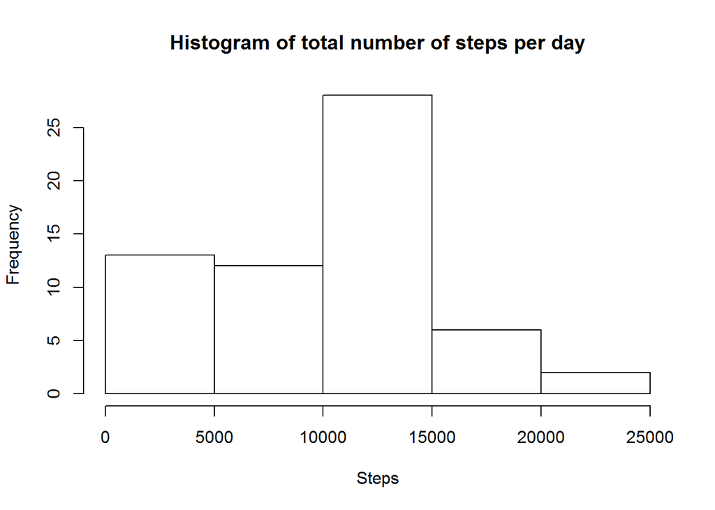

```r
hist(stepsByDay, main = "Histogram of total number of steps per day", xlab = "Steps", ylab = "Frequency")
```

#### *6. Calculate and report the mean and median total number of steps taken per day*

```r
summary(stepsByDay)
```

```
##    Min. 1st Qu.  Median    Mean 3rd Qu.    Max.
##       0    6778   10395    9354   12811   21194
```

#### *7. What is the average daily activity pattern?*

Make a time series plot (i.e. type = “l”) of the 5-minute interval (x-axis) and the average number of steps taken, averaged across all days (y-axis)

```r
avg_steps_per_interval <- aggregate(steps ~ interval, data, mean)
```

Calculate average steps per day for all intervals

```r
avg_steps_per_day <- aggregate(steps ~ date, data, mean)
```

Plot the time series with appropriate labels and heading

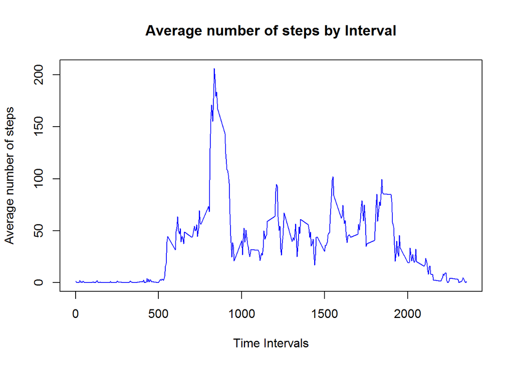

```r
plot(avg_steps_per_interval$interval, avg_steps_per_interval$steps, type = "l", col = 4, main = "Average number of steps by Interval", xlab = "Time Intervals", ylab = "Average number of steps")
```

```r
missing_dt <- data[is.na(data$steps),]
length(missing_dt$steps)
```

```
## [1] 2304
```

```r
activityDtImptd <- data
activityDtImptd$dateType <- ifelse(as.POSIXlt(activityDtImptd$date)$wday %in% c(0,6), "Weekend", "Weekday")
```

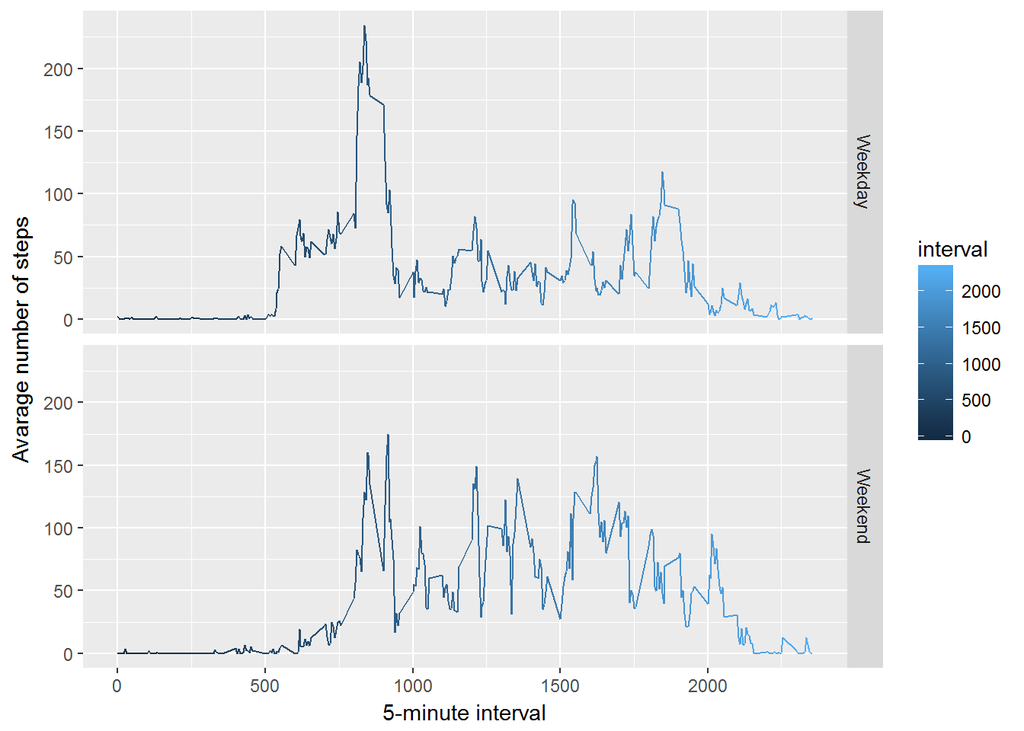

```r
averaged_ActvtDtImptd <- aggregate(steps ~ interval + dateType, data=activityDtImptd, mean)
ggplot(averaged_ActvtDtImptd, aes(interval, steps, color = interval)) +
    geom_line() +
    facet_grid(dateType ~ .) +
    xlab("5-minute interval") +
    ylab("Avarage number of steps")
```